# Set up environment

```python
import gymnasium as gym
import numpy as np
import pandas as pd
import torch
import torch.nn as nn
from stable_baselines3.common.torch_layers import BaseFeaturesExtractor
from collections import deque
```

[output not shown]

```python
import os
os.environ["KMP_DUPLICATE_LIB_OK"]="TRUE"
```

```python
class CustomLSTMExtractor(BaseFeaturesExtractor):
    """
    Custom Feature Extractor that uses an LSTM to process the time-series observation.

    :param observation_space: (gym.Space) The observation space of the environment.
    :param features_dim: (int) The dimension of the output features from the LSTM.
    """
    def __init__(self, observation_space: gym.spaces.Box, features_dim: int = 128):
        super().__init__(observation_space, features_dim)

        self.window_size = observation_space.shape[0]
        self.input_dim = observation_space.shape[1]
        self.lstm = nn.LSTM(input_size=self.input_dim, hidden_size=features_dim, batch_first=True)
        self.dropout = nn.Dropout(0.2)

    def forward(self, observations: torch.Tensor) -> torch.Tensor:
        lstm_out, _ = self.lstm(observations)
        last_step_out=lstm_out[:, -1, :]
        last_step_out=self.dropout(last_step_out)
        return last_step_out
```

# 数据准备

```python
device = torch.device("cuda" if torch.cuda.is_available() else "cpu")
device
```

```
device(type='cuda')
```

```python
tech_daily = pd.read_csv(r"data\科技股票.csv")
tech_daily.set_index('date', inplace=True)
tech_daily.columns=['AAPL','GOOG','MSFT']
tech_daily
```

| date | AAPL | GOOG | MSFT |
| --- | --- | --- | --- |
| 2015-11-09 | 27.184789 | 35.998153 | 47.105569 |
| 2015-11-10 | 26.328007 | 36.168488 | 46.540233 |
| 2015-11-11 | 26.179197 | 36.520082 | 46.661997 |
| 2015-11-12 | 26.091265 | 36.312999 | 46.374980 |
| 2015-11-13 | 25.329180 | 35.606335 | 45.957501 |
| ... | ... | ... | ... |
| 2025-11-24 | 275.920000 | 318.470000 | 474.000000 |
| 2025-11-25 | 276.970000 | 323.640000 | 476.990000 |
| 2025-11-26 | 277.550000 | 320.280000 | 485.500000 |
| 2025-11-27 | NaN | NaN | NaN |
| 2025-11-28 | 278.850000 | 320.120000 | 492.010000 |

2579 rows × 3 columns

```python
debt=pd.read_csv(r"data\无风险.csv")
debt.set_index('date', inplace=True)
debt.columns=['US_debt']
debt
```

| date | US_debt |
| --- | --- |
| 2015-11-09 | 19.950578 |
| 2015-11-10 | 19.974528 |
| 2015-11-11 | 19.934611 |
| 2015-11-12 | 19.982512 |
| 2015-11-13 | 20.030412 |
| ... | ... |
| 2025-11-24 | 23.230000 |
| 2025-11-25 | 23.280000 |
| 2025-11-26 | 23.295000 |
| 2025-11-27 | NaN |
| 2025-11-28 | 23.270000 |

2579 rows × 1 columns

```python
tmp=pd.read_csv(r"data\指数和贵金属.csv")
tmp.columns=['date','SP500','Gold']
tmp.set_index('date', inplace=True)
tmp
```

| date | SP500 | Gold |
| --- | --- | --- |
| 2015-11-09 | 2078.58 | 1090.7 |
| 2015-11-10 | 2081.72 | 1087.9 |
| 2015-11-11 | 2075.00 | 1084.2 |
| 2015-11-12 | 2045.97 | 1083.5 |
| 2015-11-13 | 2023.04 | 1081.3 |
| ... | ... | ... |
| 2025-11-24 | 6705.12 | 4133.8 |
| 2025-11-25 | 6765.88 | 4126.3 |
| 2025-11-26 | 6812.61 | 4196.1 |
| 2025-11-27 | NaN | 4189.6 |
| 2025-11-28 | 6849.09 | 4256.4 |

2579 rows × 2 columns

```python
df=pd.merge(tech_daily,debt,how='left',on='date')
df=pd.merge(df,tmp,how='left',on='date')
df['date']=pd.to_datetime(df.index)
df.set_index('date', inplace=True)
df[df.isnull().values == True]
```

| date | AAPL | GOOG | MSFT | US_debt | SP500 | Gold |
| --- | --- | --- | --- | --- | --- | --- |
| 2017-03-28 | 33.287503 | 40.767019 | 59.093436 | 20.711540 | 2358.57 | NaN |
| 2017-03-30 | 33.317596 | 41.292423 | 59.473574 | 20.694991 | 2368.06 | NaN |
| 2017-04-04 | 33.512043 | 41.444880 | 59.491676 | 20.802890 | 2360.16 | NaN |
| 2017-04-10 | 33.141667 | 40.956224 | 59.310658 | 20.811185 | 2357.16 | NaN |
| 2018-05-28 | NaN | NaN | NaN | NaN | NaN | 1297.5 |
| ... | ... | ... | ... | ... | ... | ... |
| 2025-11-27 | NaN | NaN | NaN | NaN | NaN | 4189.6 |
| 2025-11-27 | NaN | NaN | NaN | NaN | NaN | 4189.6 |
| 2025-11-27 | NaN | NaN | NaN | NaN | NaN | 4189.6 |
| 2025-11-27 | NaN | NaN | NaN | NaN | NaN | 4189.6 |
| 2025-11-27 | NaN | NaN | NaN | NaN | NaN | 4189.6 |

253 rows × 6 columns

```python
df['Cash']=10000
df
```

| date | AAPL | GOOG | MSFT | US_debt | SP500 | Gold | Cash |
| --- | --- | --- | --- | --- | --- | --- | --- |
| 2015-11-09 | 27.184789 | 35.998153 | 47.105569 | 19.950578 | 2078.58 | 1090.7 | 10000 |
| 2015-11-10 | 26.328007 | 36.168488 | 46.540233 | 19.974528 | 2081.72 | 1087.9 | 10000 |
| 2015-11-11 | 26.179197 | 36.520082 | 46.661997 | 19.934611 | 2075.00 | 1084.2 | 10000 |
| 2015-11-12 | 26.091265 | 36.312999 | 46.374980 | 19.982512 | 2045.97 | 1083.5 | 10000 |
| 2015-11-13 | 25.329180 | 35.606335 | 45.957501 | 20.030412 | 2023.04 | 1081.3 | 10000 |
| ... | ... | ... | ... | ... | ... | ... | ... |
| 2025-11-24 | 275.920000 | 318.470000 | 474.000000 | 23.230000 | 6705.12 | 4133.8 | 10000 |
| 2025-11-25 | 276.970000 | 323.640000 | 476.990000 | 23.280000 | 6765.88 | 4126.3 | 10000 |
| 2025-11-26 | 277.550000 | 320.280000 | 485.500000 | 23.295000 | 6812.61 | 4196.1 | 10000 |
| 2025-11-27 | NaN | NaN | NaN | NaN | NaN | 4189.6 | 10000 |
| 2025-11-28 | 278.850000 | 320.120000 | 492.010000 | 23.270000 | 6849.09 | 4256.4 | 10000 |

2579 rows × 7 columns

```python
df.interpolate(method='time', inplace=True)
df
```

| date | AAPL | GOOG | MSFT | US_debt | SP500 | Gold | Cash |
| --- | --- | --- | --- | --- | --- | --- | --- |
| 2015-11-09 | 27.184789 | 35.998153 | 47.105569 | 19.950578 | 2078.58 | 1090.7 | 10000 |
| 2015-11-10 | 26.328007 | 36.168488 | 46.540233 | 19.974528 | 2081.72 | 1087.9 | 10000 |
| 2015-11-11 | 26.179197 | 36.520082 | 46.661997 | 19.934611 | 2075.00 | 1084.2 | 10000 |
| 2015-11-12 | 26.091265 | 36.312999 | 46.374980 | 19.982512 | 2045.97 | 1083.5 | 10000 |
| 2015-11-13 | 25.329180 | 35.606335 | 45.957501 | 20.030412 | 2023.04 | 1081.3 | 10000 |
| ... | ... | ... | ... | ... | ... | ... | ... |
| 2025-11-24 | 275.920000 | 318.470000 | 474.000000 | 23.230000 | 6705.12 | 4133.8 | 10000 |
| 2025-11-25 | 276.970000 | 323.640000 | 476.990000 | 23.280000 | 6765.88 | 4126.3 | 10000 |
| 2025-11-26 | 277.550000 | 320.280000 | 485.500000 | 23.295000 | 6812.61 | 4196.1 | 10000 |
| 2025-11-27 | 278.200000 | 320.200000 | 488.755000 | 23.282500 | 6830.85 | 4189.6 | 10000 |
| 2025-11-28 | 278.850000 | 320.120000 | 492.010000 | 23.270000 | 6849.09 | 4256.4 | 10000 |

2579 rows × 7 columns

```python
df = df.sort_index()

print("数据日期范围:", df.index.min(), "→", df.index.max())

def generate_walk_forward_windows(index, train_years=9, test_months=12, step_months=6):
    windows = []

    start_date = index.min().normalize()
    last_date = index.max().normalize()

    current_train_start = start_date

    while True:
        train_start = current_train_start
        train_end = (
            train_start + pd.DateOffset(years=train_years) - pd.DateOffset(days=1)
        )
        test_start = train_end + pd.DateOffset(days=1)
        test_end = (
            test_start + pd.DateOffset(months=test_months) - pd.DateOffset(days=1)
        )

        if test_end > last_date:
            break

        windows.append(
            {
                "train_start": train_start,
                "train_end": train_end,
                "test_start": test_start,
                "test_end": test_end,
            }
        )

        current_train_start = current_train_start + pd.DateOffset(months=step_months)

    return windows


# 生成窗口
windows = generate_walk_forward_windows(df.index)

print(f"共生成 {len(windows)} 个滑动窗口：")
for i, w in enumerate(windows):
    print(
        f"Window {i}: "
        f"Train {w['train_start'].date()} ~ {w['train_end'].date()} | "
        f"Test {w['test_start'].date()} ~ {w['test_end'].date()}"
    )
```

```
数据日期范围: 2015-11-09 00:00:00 → 2025-11-28 00:00:00
共生成 1 个滑动窗口：
Window 0: Train 2015-11-09 ~ 2024-11-08 | Test 2024-11-09 ~ 2025-11-08
```

```python
from math import inf
import talib
import numpy as np
import pandas as pd
import gymnasium as gym
import torch
from collections import deque  # 【修复1】修正导入

class PortfolioOptimizationEnv(gym.Env):
    def __init__(
        self, tickers, window_size, start_date, end_date, initial_balance, seed=None
    ):
        super().__init__()
        self.tickers = tickers
        self.window_size = window_size
        self.initial_balance = initial_balance

        # 分别存储原始价格和指标
        self.raw_data, self.feature_data = self.get_data(tickers, start_date, end_date)
        self.n_features = self.feature_data.shape[1]

        self.action_space = gym.spaces.Box(low=0, high=1, shape=(len(tickers),))
        self.observation_space = gym.spaces.Box(
            low=-inf, high=inf, shape=(window_size, self.n_features)
        )

        self.return_window = deque(maxlen=window_size)
        self.last_action = np.ones(len(tickers)) / len(tickers)

        if seed is not None:
            np.random.seed(seed)
            self.action_space.seed(seed)
            torch.manual_seed(seed)
            if torch.cuda.is_available():
                torch.cuda.manual_seed_all(seed)

    def get_data(self, tickers, start_date, end_date):
        # 假设 df 是全局变量，建议在实际工程中作为参数传入，这里保持原样
        data = df.copy().dropna()
        data = data.loc[start_date:end_date, tickers]

        # 保存原始价格（用于计算投资组合收益）
        raw_data = data.copy()

        # 计算特征指标
        returns = data.pct_change()

        feature_list=[returns]

        volatility=data.pct_change().rolling(20).std()
        volatility.columns=[f'{col}_vol_20' for col in volatility.columns]
        feature_list.append(volatility)

        rsi_df=pd.DataFrame(index=data.index)
        for col in data.columns:
            values=data[col].values.astype(float)

            if np.all(values==values[0]):
                rsi_df[f'{col}_rsi']=50
            else:
                try:
                    rsi_values=talib.RSI(values, timeperiod=14)
                    rsi_df[f'{col}_rsi']=rsi_values
                except Exception as e:
                    print(f'RSI计算失败: {e}')
        feature_list.append(rsi_df)

        macd_df=pd.DataFrame(index=data.index)
        for col in data.columns:
            values=data[col].values.astype(float)

            if np.all(values==values[0]):
                macd_df[f'{col}_macd']=0
            else:
                try:
                    macd_values=talib.MACD(values, fastperiod=12, slowperiod=26, signalperiod=9)[0]
                    macd_df[f'{col}_macd']=macd_values
                except Exception as e:
                    print(f'MACD计算失败: {e}')
        feature_list.append(macd_df)

        feature_data=pd.concat(feature_list, axis=1)
        feature_data=feature_data.dropna()
        raw_data=raw_data.reindex(feature_data.index).dropna()

        return raw_data, feature_data

    def reset(self, seed=None):
        self.balance = self.initial_balance
        self.current_step = self.window_size

        self.return_window.clear()
        self.last_action = np.ones(len(self.tickers)) / len(self.tickers)

        # 使用特征数据作为观察
        obs = self.feature_data.iloc[
            self.current_step - self.window_size : self.current_step
        ].values
        info = {"balance": self.balance}
        return obs, info

    def step(self, action):
        # SAC已经输出归一化的动作，因此不需要进行softmax
        action = np.asarray(action).ravel()
        action = np.clip(action, 0, 1)
        action = action / np.sum(action + 1e-8)

        prev_balance = self.balance

        # 从原始价格计算实际收益
        # 确保 current_step 不越界
        if self.current_step >= len(self.raw_data):
            done = True
            # 返回最后一个有效观察
            obs = self.feature_data.iloc[
                self.current_step - self.window_size : self.current_step
            ].values
            return obs, 0, True, False, {"balance": self.balance}

        current_price = self.raw_data.iloc[self.current_step].values[
            : len(self.tickers)
        ]
        prev_price = self.raw_data.iloc[self.current_step - 1].values[
            : len(self.tickers)
        ]
        asset_returns = current_price / prev_price - 1

        self.return_window.append(asset_returns)

        # 基础奖励：投资组合收益
        portfolio_return = np.sum(asset_returns * action)
        self.balance = self.balance * (1 + portfolio_return)

        volatility = np.std(self.return_window) if len(self.return_window) > 10 else 0.01

        turnover = np.sum(np.abs(action - self.last_action))
        cost = turnover
        self.last_action = action

        # 总奖励
        lambda_turnover = 0.001
        reward = portfolio_return / (volatility + 1e-6) - lambda_turnover * turnover

        self.current_step += 1
        done = self.current_step >= len(self.raw_data) - 1

        # 【修复2】修正观察窗口逻辑，与 reset 保持一致，向后看 window_size
        obs = self.feature_data.iloc[
            self.current_step - self.window_size : self.current_step
        ].values

        terminated = bool(done)
        truncated = False
        info = {"balance": self.balance}

        return obs, reward, terminated, truncated, info
```

```python
tickers = df.columns.tolist()
window_size = 30
start_date = '2015-11-09'
end_date = '2025-11-28'
initial_balance = 10000
seed = 8

env = PortfolioOptimizationEnv(
    tickers,
    window_size,
    start_date,
    end_date,
    initial_balance,
    seed)

# Get the initial state
state = env.reset(seed=seed)
# Sample and execute a random action
action = env.action_space.sample()
next_state, reward, terminated, truncated, info = env.step(action)
done = bool(terminated or truncated)
print(f"Action: {action}")
print(f"Reward: {reward}")
print(f"Balance: {info['balance']}")
print(f"Done: {done}")
```

```
Action: [0.32697228 0.98727685 0.31871083 0.78854895 0.86989653 0.39108482
 0.4378819 ]
Reward: 0.3211637388834304
Balance: 10032.162297035655
Done: False
```

# Training DRL agent

## SAC

```python
policy_kwargs = dict(
    features_extractor_class=CustomLSTMExtractor,
    features_extractor_kwargs=dict(features_dim=128), # Output dimension of LSTM
    net_arch=[128, 64] # MLP layers after LSTM
)
```

```python
from stable_baselines3 import SAC
from stable_baselines3.common.vec_env import DummyVecEnv, VecNormalize
from stable_baselines3.common.monitor import Monitor
import numpy as np
import pandas as pd
import matplotlib.pyplot as plt
import os

# 日志目录
log_dir = "./sb3_logs_wf"
os.makedirs(log_dir, exist_ok=True)


# 为某个时间段构建一个 env 的工厂函数
def make_env_for_period(start_date_str, end_date_str, monitor_file=None):
    def _init():
        env_ = PortfolioOptimizationEnv(
            tickers=tickers,
            window_size=window_size,
            start_date=start_date_str,
            end_date=end_date_str,
            initial_balance=initial_balance,
            seed=seed,
        )
        if monitor_file is not None:
            env_ = Monitor(env_, filename=monitor_file)
        return env_

    return _init


# 保存每个窗口的测试结果
wf_results = []

TOTAL_TIMESTEPS = 10_000

for i, w in enumerate(windows):
    print("=" * 80)
    print(f"Window {i}")
    print(f"Train: {w['train_start'].date()} ~ {w['train_end'].date()}")
    print(f"Test : {w['test_start'].date()} ~ {w['test_end'].date()}")

    train_start_str = w["train_start"].strftime("%Y-%m-%d")
    train_end_str = w["train_end"].strftime("%Y-%m-%d")
    test_start_str = w["test_start"].strftime("%Y-%m-%d")
    test_end_str = w["test_end"].strftime("%Y-%m-%d")

    # -------- 1) 构建训练环境 + 归一化 --------
    monitor_path = os.path.join(log_dir, f"monitor_train_window_{i}.csv")

    vec_train_env = DummyVecEnv(
        [make_env_for_period(train_start_str, train_end_str, monitor_file=monitor_path)]
    )
    vec_train_env = VecNormalize(
        vec_train_env, norm_obs=True, norm_reward=False, clip_obs=10.0
    )

    # -------- 2) 训练 SAC --------
    model = SAC(
        "MlpPolicy",
        vec_train_env,
        verbose=1,
        device=device,
        policy_kwargs=policy_kwargs,
        # 下面这些超参数可以之后再细调
        learning_rate=3e-4,
        batch_size=256,
        buffer_size=200_000,
        gamma=0.99,
        tau=0.005,
        ent_coef="auto",
        train_freq=(256, "step"),
        gradient_steps=-1,
    )

    model.learn(total_timesteps=TOTAL_TIMESTEPS)

    model_path = os.path.join(log_dir, f"sac_window_{i}.zip")
    vecnorm_path = os.path.join(log_dir, f"sac_vecnorm_window_{i}.pkl")
    model.save(model_path)
    vec_train_env.save(vecnorm_path)
    print(f"Saved model to {model_path}")
    print(f"Saved VecNormalize to {vecnorm_path}")

    # -------- 3) 构建测试环境（使用同一归一化统计） --------
    test_env_raw = DummyVecEnv(
        [make_env_for_period(test_start_str, test_end_str, monitor_file=None)]
    )
    test_env = VecNormalize.load(vecnorm_path, test_env_raw)
    test_env.training = False
    test_env.norm_reward = False

    # -------- 4) 在测试集上回测该窗口策略 --------
    obs = test_env.reset()
    dones = [False]
    balances = []
    rewards = []
    weights_seq = []

    while not dones[0]:
        action, _ = model.predict(obs, deterministic=True)
        obs, reward, dones, infos = test_env.step(action)
        rewards.append(float(reward[0]))
        balances.append(float(infos[0].get("balance", np.nan)))
        weights_seq.append(infos[0].get("weights", None))

    base_env = test_env.envs[0]
    while hasattr(base_env, "env"):
        base_env = base_env.env
    price_index = base_env.raw_data.index
    start_idx = window_size
    end_idx = start_idx + len(balances)
    dates = price_index[start_idx:end_idx]

    balances_arr = np.asarray(balances, dtype=float)

    def analysis(balances_arr,dates):
        rets = (
            balances_arr[1:] / balances_arr[:-1] - 1.0
            if len(balances_arr) > 1
            else np.array([])
        )

        # 简单算一下每个窗口的指标（年化收益、波动、Sharpe）
        def infer_ppy(idx):
            if isinstance(idx, pd.DatetimeIndex) and len(idx) >= 2:
                deltas = np.diff(idx.view("int64")) / 1e9 / 86400.0
                median_days = np.median(deltas) if len(deltas) else 1.0
                if median_days <= 0:
                    return 252.0
                return 365.25 / median_days
            return 252.0

        PPY = infer_ppy(dates)

        if len(rets) > 1:
            total_growth = balances_arr[-1] / balances_arr[0]
            ann_return_geom = total_growth ** (PPY / len(rets)) - 1.0
            ann_vol = np.std(rets) * np.sqrt(PPY)
            sharpe = ann_return_geom / ann_vol
        else:
            total_growth = np.nan
            ann_return_geom = np.nan
            ann_vol = np.nan
            sharpe = np.nan

        wf_results.append(
            {
                "window_id": i,
                "train_start": w["train_start"],
                "train_end": w["train_end"],
                "test_start": w["test_start"],
                "test_end": w["test_end"],
                "test_steps": len(rets),
                "start_wealth": balances_arr[0] if len(balances_arr) > 0 else np.nan,
                "end_wealth": balances_arr[-1] if len(balances_arr) > 0 else np.nan,
                "total_growth": total_growth,
                "ann_return": ann_return_geom,
                "ann_vol": ann_vol,
                "sharpe": sharpe,
            }
        )

        print(f"Window {i} 测试结束：")
        print(f"  终值资产: {balances_arr[-1]:.2f}  (初始 {balances_arr[0]:.2f})")
        print(f"  总增长倍数: {total_growth:.4f}")
        print(f"  年化收益:  {ann_return_geom:.2%}")
        print(f"  年化波动:  {ann_vol:.2%}")
        print(f"  Sharpe:    {sharpe:.3f}")

        return wf_results


wf_results_df = pd.DataFrame(analysis(balances_arr,dates))
wf_results_df
```

```
================================================================================
Window 0
Train: 2015-11-09 ~ 2024-11-08
Test : 2024-11-09 ~ 2025-11-08
Using cuda device
---------------------------------
| rollout/           |          |
|    ep_len_mean     | 2.24e+03 |
|    ep_rew_mean     | 138      |
| time/              |          |
|    episodes        | 4        |
|    fps             | 40       |
|    time_elapsed    | 218      |
|    total_timesteps | 8964     |
| train/             |          |
|    actor_loss      | -27.1    |
|    critic_loss     | 0.118    |
|    ent_coef        | 0.0708   |
|    ent_coef_loss   | -30.8    |
|    learning_rate   | 0.0003   |
|    n_updates       | 8960     |
---------------------------------
Saved model to ./sb3_logs_wf\sac_window_0.zip
Saved VecNormalize to ./sb3_logs_wf\sac_vecnorm_window_0.pkl
Window 0 测试结束：
  终值资产: 11980.71  (初始 10016.09)
  总增长倍数: 1.1961
  年化收益:  40.10%
  年化波动:  18.24%
  Sharpe:    2.199
```

|  | window_id | train_start | train_end | test_start | test_end | test_steps | start_wealth | end_wealth | total_growth | ann_return | ann_vol | sharpe |
| --- | --- | --- | --- | --- | --- | --- | --- | --- | --- | --- | --- | --- |
| 0 | 0 | 2015-11-09 | 2024-11-08 | 2024-11-09 | 2025-11-08 | 194 | 10016.090884 | 11980.706601 | 1.196146 | 0.401028 | 0.1824 | 2.198616 |

# 画图

```python
tickers = df.columns.tolist()
```

```python
plot_start = start_date
plot_end = end_date


def make_backtest_env():
    return PortfolioOptimizationEnv(
        tickers=tickers,
        window_size=window_size,
        start_date=plot_start,
        end_date=plot_end,
        initial_balance=initial_balance,
        seed=seed,
    )
```

```python
# 1. 创建环境
vec_backtest_env = DummyVecEnv([make_backtest_env])

# 2. 【核心修复】加载归一化统计量！防止数值爆炸导致的崩溃
# 注意：这里需要确保 sac_vecnorm_window_0.pkl 文件存在
vecnorm_path = os.path.join(log_dir, "sac_vecnorm_window_0.pkl")
if os.path.exists(vecnorm_path):
    vec_backtest_env = VecNormalize.load(vecnorm_path, vec_backtest_env)
    vec_backtest_env.training = False
    vec_backtest_env.norm_reward = False
else:
    print("警告：未找到归一化文件，使用原始数据可能会导致模型表现极差或崩溃！")
```

```python
# 3. 运行回测
obs = vec_backtest_env.reset()
done = False
balances = []
dates = []

while not done:
    # deterministic=True 意味着使用训练好的最优策略
    action, _ = model.predict(obs, deterministic=True)
    obs, rewards, dones, infos = vec_backtest_env.step(action)
    done = bool(dones[0])

    balances.append(float(infos[0]["balance"]))

    # 获取日期 (这部分逻辑保持不变)
    base_env = vec_backtest_env.envs[0]
    while hasattr(base_env, "env"): # 解包 wrapper 找到最底层的 env
        base_env = base_env.env
    # 注意：这里用 current_step - 1 因为 step() 已经加了 1
    cur_idx = base_env.current_step - 1
    if cur_idx < len(base_env.raw_data):
        dates.append(base_env.raw_data.index[cur_idx])

# 4. 生成绘图数据
equity = pd.Series(balances, index=pd.to_datetime(dates[:len(balances)]), name="Strategy")
norm_equity = equity / equity.iloc[0]
```

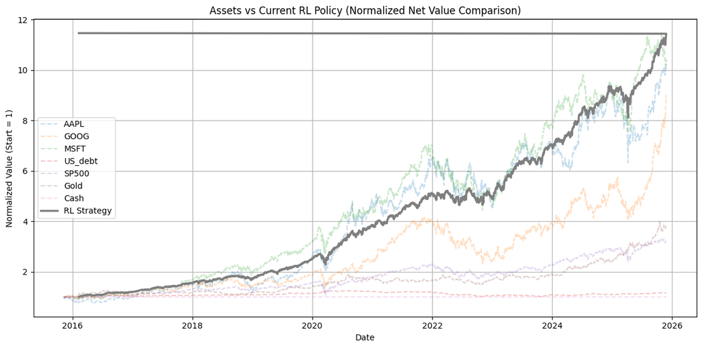

```python
from matplotlib.lines import lineStyles
import matplotlib.pyplot as plt

asset_cols = tickers
prices = df.loc[plot_start:plot_end, asset_cols].copy()
norm_prices = prices / prices.iloc[0]

plt.figure(figsize=(12, 6))

for col in asset_cols:
    plt.plot(norm_prices.index, norm_prices[col], label=col, alpha=0.25,linestyle='--')

plt.plot(norm_equity.index, norm_equity, label="RL Strategy", linewidth=2.5)

plt.title("Assets vs Current RL Policy (Normalized Net Value Comparison)")
plt.xlabel("Date")
plt.ylabel("Normalized Value (Start = 1)")
plt.legend()
plt.grid(True)
plt.tight_layout()
plt.show()
```

```python
rets = norm_equity.pct_change().dropna()

start = norm_equity.iloc[0]
end = norm_equity.iloc[-1]

total_growth = end / start
ann_return = (1 + rets).prod() ** (252 / len(rets)) - 1
ann_vol = rets.std(ddof=1) * np.sqrt(252)

sharpe = ann_return / ann_vol if ann_vol > 0 else np.nan

print(f"终值资产:\t{end:.2f}  (初始 {start:.2f})")
print(f"总增长倍数:\t{total_growth:.4f}")
print(f"年化收益:\t{ann_return*100:.2f}%")
print(f"年化波动:\t{ann_vol*100:.2f}%")
print(f"Sharpe:\t\t{sharpe:.2f}")
```

```
终值资产:	11.46  (初始 1.00)
总增长倍数:	11.4645
年化收益:	27.70%
年化波动:	13.75%
Sharpe:		2.01
```

# 修改部分

添加了科技股票、国债、标普500和黄金等数据作为环境输入特征

## 收益严重偏大，进行修改：

=== Portfolio Performance (deterministic rollout) === Periods per year (inferred): 252.00 Start wealth: 10297.47 End wealth: 23731074.08 Total growth: 2304.553868 CAGR: 804.485651% Ann. Return (geom from equity): 804.485651% Ann. Vol: 22.710210% Sharpe (rf=0): 9.8502 Max Drawdown: -5.59% Calmar: 143.9561

### 1、对vec_env进行了归一化处理

=== Portfolio Performance (deterministic rollout) === Periods per year (inferred): 252.00 Start wealth: 10180.25 End wealth: 1013360.39 Total growth: 99.541782 CAGR: 270.067928% Ann. Return (geom from equity): 270.067928% Ann. Vol: 22.074986% Sharpe (rf=0): 6.0514 Max Drawdown: -8.50% Calmar: 31.7818

### 2、调整奖励函数

用协方差矩阵估计组合波动 添加每次交易成本千一

=== Portfolio Performance (deterministic rollout) === Periods per year (inferred): 252.00 Start wealth: 10055.45 End wealth: 54941.09 Total growth: 5.463811 CAGR: 62.092061% Ann. Return (geom from equity): 62.092061% Ann. Vol: 17.712724% Sharpe (rf=0): 2.8174 Max Drawdown: -11.18% Calmar: 5.5563

### 3、更换为sac算法

=== Portfolio Performance (deterministic rollout) === Periods per year (inferred): 252.00 Start wealth: 10145.52 End wealth: 22875.43 Total growth: 2.254731 CAGR: 26.016893% Ann. Return (geom from equity): 26.016893% Ann. Vol: 14.523819% Sharpe (rf=0): 1.6653 Max Drawdown: -12.48% Calmar: 2.0840

删除了step函数中对动作的softmax处理

=== Portfolio Performance (deterministic rollout) === Periods per year (inferred): 252.00 Start wealth: 10096.53 End wealth: 36203.07 Total growth: 3.585696 CAGR: 43.791829% Ann. Return (geom from equity): 43.791829% Ann. Vol: 12.005115% Sharpe (rf=0): 3.0874 Max Drawdown: -8.52% Calmar: 5.1418

# 优化奖励函数权重

benchmark:

lambda_risk = 1 lambda_turnover = 0.01 reward = base_reward - lambda_risk * risk_penalty - lambda_turnover * cost

=== Portfolio Performance (deterministic rollout) === Periods per year (inferred): 252.00 Start wealth: 10164.10 End wealth: 39643.65 Total growth: 3.900359 CAGR: 47.273482% Ann. Return (geom from equity): 47.273482% Ann. Vol: 17.140595% Sharpe (rf=0): 2.3455 Max Drawdown: -13.67% Calmar: 3.4585

# 加入lstm